# Practical Machine Learning Course Project

Joyvalerie Mondejar

Last Updated:* January 26, 2021

*Date Created*: January 14, 2020

## Background

Using devices such as Jawbone Up, Nike FuelBand, and Fitbit it is now possible to collect a large amount of data about personal activity relatively inexpensively. These type of devices are part of the quantified self movement – a group of enthusiasts who take measurements about themselves regularly to improve their health, to find patterns in their behavior, or because they are tech geeks. One thing that people regularly do is quantify how much of a particular activity they do, but they rarely quantify how well they do it. In this project, your goal will be to use data from accelerometers on the belt, forearm, arm, and dumbell of 6 participants. They were asked to perform barbell lifts correctly and incorrectly in 5 different ways. More information is available from the website here: http://groupware.les.inf.puc-rio.br/har (see the section on the Weight Lifting Exercise Dataset).

## Getting and Cleaning Data

The training data for this project are available here: https://d396qusza40orc.cloudfront.net/predmachlearn/pml-training.csv

The test data are available here: https://d396qusza40orc.cloudfront.net/predmachlearn/pml-testing.csv

The data for this project come from this source: http://groupware.les.inf.puc-rio.br/har.

Loading data

```r
trainingSet <- read.csv("https://d396qusza40orc.cloudfront.net/predmachlearn/pml-training.csv")
testingSet <- read.csv("https://d396qusza40orc.cloudfront.net/predmachlearn/pml-testing.csv")
```

Cleaning Data

```r
# see error proportion
NAProportion <- round(colMeans(is.na(trainingSet)), 2)
head(NAProportion, 20)
```

```
##                    X            user_name raw_timestamp_part_1
##                 0.00                 0.00                 0.00
## raw_timestamp_part_2       cvtd_timestamp           new_window
##                 0.00                 0.00                 0.00
##           num_window            roll_belt           pitch_belt
##                 0.00                 0.00                 0.00
##             yaw_belt     total_accel_belt   kurtosis_roll_belt
##                 0.00                 0.00                 0.00
##  kurtosis_picth_belt    kurtosis_yaw_belt   skewness_roll_belt
##                 0.00                 0.00                 0.00
## skewness_roll_belt.1    skewness_yaw_belt        max_roll_belt
##                 0.00                 0.00                 0.98
##       max_picth_belt         max_yaw_belt
##                 0.98                 0.00
```

```r
table(NAProportion)
```

```
## NAProportion
##    0 0.98
##   93   67
```

```r
# 93 columns have complete data, while 67 columns have 98% missing data
```

```r
# find index of the complete columns minus the first 7 columns since they seems (administrative data) to be not useful in predicting the outcome variable classe
index <- which(NAProportion == 0)[-c(1:7)]
# subset the data
trainData <- trainingSet[, index]
testData <- testingSet[, index]
dim(trainData)
```

```
## [1] 19622    86
```

```r
dim(testData)
```

```
## [1] 20 86
```

```r
remove_cols <- nearZeroVar(trainData)     # removed the 33 columns with near zero variance
trainData <- trainData[, -remove_cols]
testData <- testData[, -remove_cols]
dim(trainData)
```

```
## [1] 19622    53
```

```r
dim(testData)
```

```
## [1] 20 53
```

```r
trainData$classe <- as.factor(trainData$classe)
```

## Cross Validation

```r
set.seed(3475)
inTrain <- createDataPartition(y = trainData$classe, p = 0.7, list = FALSE)
trainData <- trainData[inTrain, ]
validData <- trainData[-inTrain, ]
rbind(trainData = dim(trainData), validData = dim(validData), test = dim(testData))
```

```
##            [,1] [,2]
## trainData 13737   53
## validData  4118   53
## test         20   53
```

We will now train the data using the remaining 52 variables.

## Model Building

### Prediction with Classication Trees

```r
decisionTreeMod <- train(classe ~ ., data = trainData, method = "rpart")  # constructs trees based on the outcome and predictors
print(decisionTreeMod$finalModel)  # returns text summary of all nodes/spits in the constructed tree
```

```
## n= 13737
##
## node), split, n, loss, yval, (yprob)
##       * denotes terminal node
##
##  1) root 13737 9831 A (0.28 0.19 0.17 0.16 0.18)
##    2) roll_belt< 130.5 12588 8692 A (0.31 0.21 0.19 0.18 0.11)
##      4) pitch_forearm< -33.05 1134   15 A (0.99 0.013 0 0 0) *
##      5) pitch_forearm>=-33.05 11454 8677 A (0.24 0.23 0.21 0.2 0.12)
##       10) magnet_dumbbell_y< 439.5 9702 6982 A (0.28 0.18 0.24 0.19 0.11)
##         20) roll_forearm< 122.5 5994 3567 A (0.4 0.18 0.19 0.17 0.061) *
##         21) roll_forearm>=122.5 3708 2511 C (0.079 0.18 0.32 0.23 0.18) *
##       11) magnet_dumbbell_y>=439.5 1752  852 B (0.033 0.51 0.04 0.22 0.19) *
##    3) roll_belt>=130.5 1149   10 E (0.0087 0 0 0 0.99) *
```

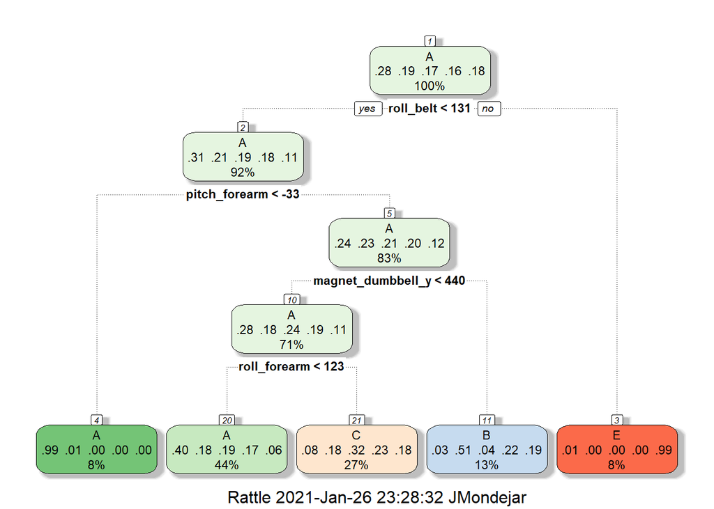

```r
# Plots the classification tree with all nodes/splits
fancyRpartPlot(decisionTreeMod$finalModel)   # from rattle package
```

```r
# use the model to predict on validation dataset
predictTreeMod <- predict(decisionTreeMod, newdata = validData)
# confusion matrix of predicted results
cmtree <- confusionMatrix(predictTreeMod, validData$classe)
cmtree
```

```
## Confusion Matrix and Statistics
##
##           Reference
## Prediction    A    B    C    D    E
##          A 1056  306  327  303  101
##          B   15  272   15  121  126
##          C   95  201  388  261  186
##          D    0    0    0    0    0
##          E    3    0    0    0  342
##
## Overall Statistics
##
##                Accuracy : 0.4998
##                  95% CI : (0.4844, 0.5151)
##     No Information Rate : 0.2839
##     P-Value [Acc > NIR] : < 2.2e-16
##
##                   Kappa : 0.3473
##
##  Mcnemar's Test P-Value : NA
##
## Statistics by Class:
##
##                      Class: A Class: B Class: C Class: D Class: E
## Sensitivity            0.9033  0.34917  0.53151   0.0000  0.45298
## Specificity            0.6484  0.91704  0.78070   1.0000  0.99911
## Pos Pred Value         0.5045  0.49545  0.34306      NaN  0.99130
## Neg Pred Value         0.9442  0.85794  0.88550   0.8337  0.89054
## Prevalence             0.2839  0.18917  0.17727   0.1663  0.18334
## Detection Rate         0.2564  0.06605  0.09422   0.0000  0.08305
## Detection Prevalence   0.5083  0.13332  0.27465   0.0000  0.08378
## Balanced Accuracy      0.7758  0.63310  0.65610   0.5000  0.72604
```

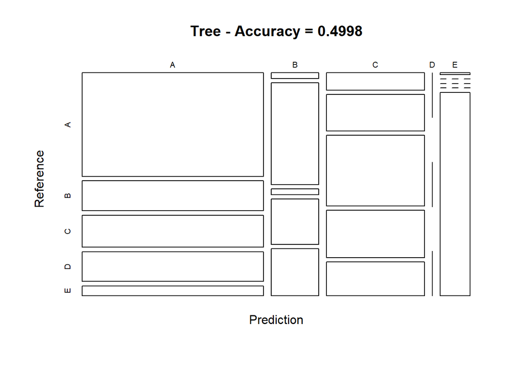

```r
# plot matrix results
plot(cmtree$table, col = cmtree$byClass,
     main = paste("Tree - Accuracy =", round(cmtree$overall['Accuracy'], 4)))
```

The decision tree has accuracy of 0.4998 and therefore the out-of-sample error 0.5002

### Prediction using Random Forest

```r
# Fitting a random forest model
set.seed(3475)
controlRF <- trainControl(method = "cv", number = 10, verboseIter = FALSE)
t1 <- Sys.time()
rfMod <- train(classe ~ ., data = trainData, method = "rf", prox = TRUE, trControl = controlRF)
rfMod
```

```
## Random Forest
##
## 13737 samples
##    52 predictor
##     5 classes: 'A', 'B', 'C', 'D', 'E'
##
## No pre-processing
## Resampling: Cross-Validated (10 fold)
## Summary of sample sizes: 12364, 12363, 12362, 12363, 12364, 12363, ...
## Resampling results across tuning parameters:
##
##   mtry  Accuracy   Kappa
##    2    0.9918470  0.9896859
##   27    0.9914104  0.9891340
##   52    0.9847133  0.9806598
##
## Accuracy was used to select the optimal model using the largest value.
## The final value used for the model was mtry = 2.
```

```r
t2 <- Sys.time()
t2 - t1
```

```
## Time difference of 1.851007 hours
```

```r
rfMod$finalModel
```

```
##
## Call:
##  randomForest(x = x, y = y, mtry = param$mtry, proximity = TRUE)
##                Type of random forest: classification
##                      Number of trees: 500
## No. of variables tried at each split: 2
##
##         OOB estimate of  error rate: 0.71%
## Confusion matrix:
##      A    B    C    D    E  class.error
## A 3905    1    0    0    0 0.0002560164
## B   16 2632   10    0    0 0.0097817908
## C    0   22 2370    4    0 0.0108514190
## D    0    0   36 2213    3 0.0173179396
## E    0    0    2    4 2519 0.0023762376
```

```r
getTrainPerf(rfMod)
```

```
##   TrainAccuracy TrainKappa method
## 1      0.991847  0.9896859     rf
```

```r
# predcition on testData
predictRfMod <- predict(rfMod, newdata = validData)
cmRf <-  confusionMatrix(predictRfMod, validData$classe)
cmRf
```

```
## Confusion Matrix and Statistics
##
##           Reference
## Prediction    A    B    C    D    E
##          A 1169    0    0    0    0
##          B    0  779    0    0    0
##          C    0    0  730    0    0
##          D    0    0    0  685    0
##          E    0    0    0    0  755
##
## Overall Statistics
##
##                Accuracy : 1
##                  95% CI : (0.9991, 1)
##     No Information Rate : 0.2839
##     P-Value [Acc > NIR] : < 2.2e-16
##
##                   Kappa : 1
##
##  Mcnemar's Test P-Value : NA
##
## Statistics by Class:
##
##                      Class: A Class: B Class: C Class: D Class: E
## Sensitivity            1.0000   1.0000   1.0000   1.0000   1.0000
## Specificity            1.0000   1.0000   1.0000   1.0000   1.0000
## Pos Pred Value         1.0000   1.0000   1.0000   1.0000   1.0000
## Neg Pred Value         1.0000   1.0000   1.0000   1.0000   1.0000
## Prevalence             0.2839   0.1892   0.1773   0.1663   0.1833
## Detection Rate         0.2839   0.1892   0.1773   0.1663   0.1833
## Detection Prevalence   0.2839   0.1892   0.1773   0.1663   0.1833
## Balanced Accuracy      1.0000   1.0000   1.0000   1.0000   1.0000
```

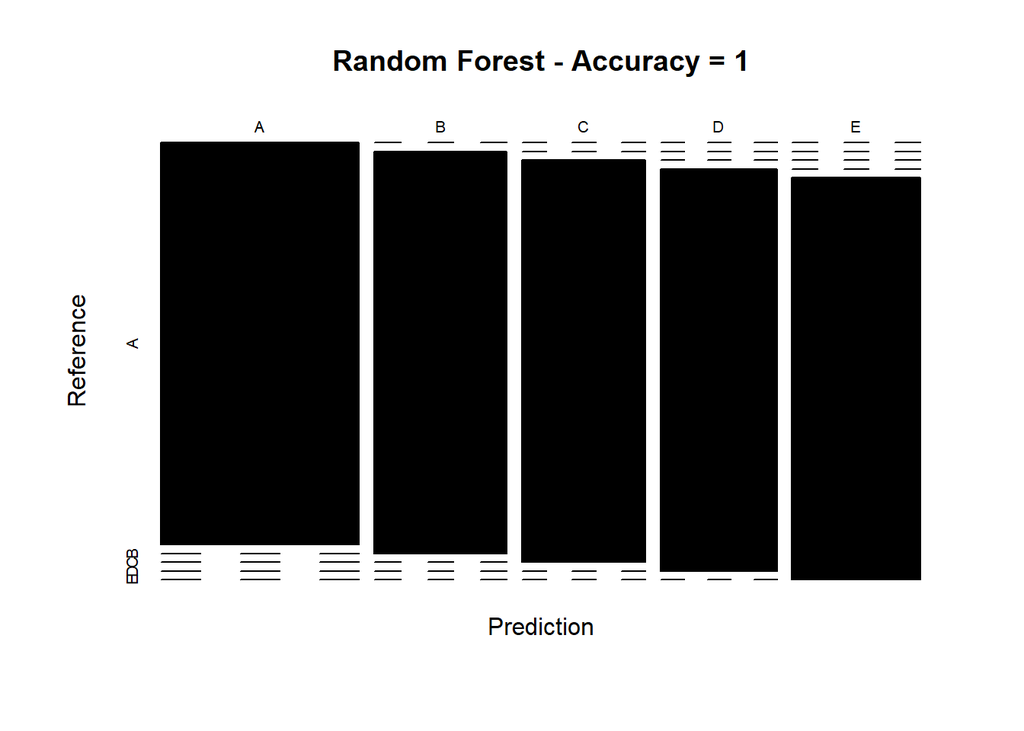

```r
# plot matrix results
plot(cmRf$table, col = cmRf$byClass,
     main = paste("Random Forest - Accuracy =",
                  round(cmRf$overall['Accuracy'], 4)))
```

### Prediction using Generalized Boosted Model

```r
set.seed(3475)
controlGBM <- trainControl(method = "repeatedcv", number = 5, repeats = 1)
t1 <- Sys.time()
gbMod <- train(classe ~ ., data = trainData, method = "gbm", trControl = controlGBM, verbose = FALSE)
t2 <- Sys.time()
t2 - t1
```

```
## Time difference of 5.729508 mins
```

```r
gbMod$finalModel
```

```
## A gradient boosted model with multinomial loss function.
## 150 iterations were performed.
## There were 52 predictors of which 52 had non-zero influence.
```

```r
# prediction on validData
predictgbMod <- predict(gbMod, newdata = validData)
cmGb <- confusionMatrix(predictgbMod, validData$classe)
cmGb
```

```
## Confusion Matrix and Statistics
##
##           Reference
## Prediction    A    B    C    D    E
##          A 1158   19    0    1    0
##          B    5  746   21    2    1
##          C    6   14  704   15    1
##          D    0    0    5  662    7
##          E    0    0    0    5  746
##
## Overall Statistics
##
##                Accuracy : 0.9752
##                  95% CI : (0.97, 0.9798)
##     No Information Rate : 0.2839
##     P-Value [Acc > NIR] : < 2.2e-16
##
##                   Kappa : 0.9687
##
##  Mcnemar's Test P-Value : NA
##
## Statistics by Class:
##
##                      Class: A Class: B Class: C Class: D Class: E
## Sensitivity            0.9906   0.9576   0.9644   0.9664   0.9881
## Specificity            0.9932   0.9913   0.9894   0.9965   0.9985
## Pos Pred Value         0.9830   0.9626   0.9514   0.9822   0.9933
## Neg Pred Value         0.9963   0.9901   0.9923   0.9933   0.9973
## Prevalence             0.2839   0.1892   0.1773   0.1663   0.1833
## Detection Rate         0.2812   0.1812   0.1710   0.1608   0.1812
## Detection Prevalence   0.2861   0.1882   0.1797   0.1637   0.1824
## Balanced Accuracy      0.9919   0.9745   0.9769   0.9815   0.9933
```

The generalized boosting model has accuracy of 0.98 and therefore the out-of-sample error is 0.02

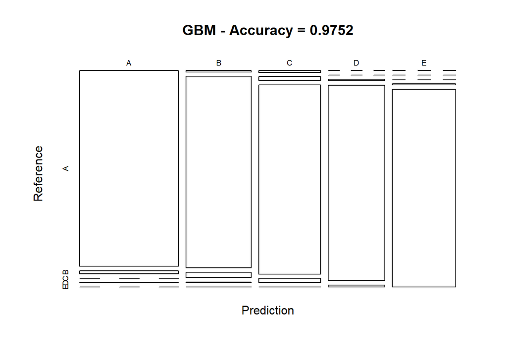

```r
# plot matrix results
plot(cmGb$table, col = cmGb$byClass,
     main = paste("GBM - Accuracy =", round(cmGb$overall['Accuracy'], 4)))
```

## Decision

The accuracy of three classification models above are:  
a. Decision Tree: 0.4998  
b. Random Forest: 1  
c. Generalized Boosted Model: ~0.98

So, considering the model with the highest accuracy the Ramdom Forest model will be applied to predict the 20 different test cases.

```r
predictTest <- predict(rfMod, newdata = testData)
predictTest
```

```
##  [1] B A B A A E D B A A B C B A E E A B B B
## Levels: A B C D E
```